# Interfaz de Rstudio

Alejandro

9/15/2020

## RStudio

RStudio es un entorno de desarrollo integrado (IDE) para el lenguaje de programación R.

## Partes de RStudio

[figure not shown]

Figura 1:Rstudio

La interfaz de RStudio se divide en cuatro paneles y un menú superior.

- **La consola**

En la consola de la interfaz de RStudio se pueden hacer cálculos y operaciones matemáticas. La consola se puede usar como una calculadora:

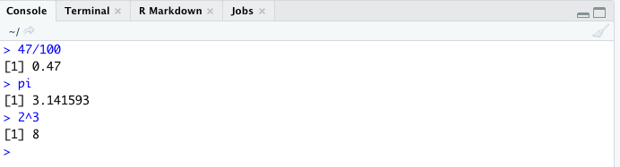

Figura 2:Consola

- **El editor**

En este panel se crean y modifican los scripts. Un script es un documento de texto en el que se escriben líneas de código R para el análisis de datos(archivos que tienen extensión .R) y para crear documentos (archivos con extensión .Rmd). En las líneas de código de R se tienen funciones y comentarios de lo que se va realizando. Así, la utilidad de poder escribir scripts nos ayuda a poder leer, limpiar, visualizar datos, escribir documentos y poder reproducir o verificar (pueden ser útiles en auditorias) estos en un futuro.

[figure not shown]

- **El entorno de variables**

[figure not shown]

Figura 4: Entorno de variables

- **Las utilidades**

Este panel se tiene la pestaña de archivos (Files) en el que se puede navegar como si fuese un explorador, en la pestaña de gráficas (Plots) podemos movernos entre todas las visualizaciones que hayamos hecho, hacer zoom y guardar las gráficas. En la pestaña Packages se pueden instalar o cargar paquetes. Por otra parte, en la pestaña Help se puede obtener ayuda de las funciones de R. Por último, en la pestaña Viewer se pueden ver gráficos interactivos.

[figure not shown]

Figura 5:Utilidades

El menú superior tiene varias opciones de configuración y ayuda.

## Cambiar el color del fondo

Click en Tools -> Global options -> Appearance

Elegir un tema en la sección *Editor theme:* Click en Apply para ver como cambia el color de el entorno de RStudio.

Al haber elegido un tema click en OK.

[figure not shown]

Figura 6:Cambiar fondo de RStudio

## Ver Hojas de referencia

Se puede ver un resumen de Rstudio y de algunos paquetes de R.

Help -> Cheatsheets

[figure not shown]

Figura 7:Hojas de referencia